# Predicting the best place to open a restaurant in Miami

## 1. Introduction

### 1.1. Background

Miami is a coastal metropolis located in Miami-Dade County in southeastern Florida, United States. It is the forty second largest city in the United States. Miami, however, is one of the core cities in a metropolitan area which is the third most populous metropolis on the East coast of the United States, and it is the seventh largest in the country.

Miami being a major center and leader in finance, commerce, culture, arts, and international trade, there is a big mixity in this city, making it a great place for opportunities like opening a new restaurant. With more than 50 new restaurants opened in the previous 12 months, despite the Covid-19 pandemic, Miami sort of becomes the new eden garden of customers ! Indeed, Miami restaurants, which have been allowed to operate at 100 percent capacity since October, are packed. And guests all over the city are having a wild time, enjoying the great weather and the incredible feeling of the wonderful city.

### 1.2. Problem description

So Miami seems to be the perfect city to open a new restaurant. But how can one be sure the kind of restaurant he wants to open is a good idea ? And how should we find the best place to open it ? Let's say, for example, that an italian brand want to open a new italian restaurant in Miami. After a study of the city, it looks like the most succesfull italian restaurant is a pizza place located in Park West, being always full of people. The best idea will then be to open another italian restaurant, in a similar neighborhood of Park West, but also being sure than the density of italian restaurant in this neighborhood is as small as possible. Anyway, with 25 neighborhoods in Miami, some of them being composed of sub-neighborhoods, it can be quite complicated to find the best place. This is why we propose here an AI-assisted analysis to find the best place to open a new commerce, according to the type of venues one wants to open.

[figure not shown]

### 1.3. Interests

Obviously, a lot of people and brands could be interested in our methodology, as long as it can be quickly translated to any kind of venues (restaurant, fitness club, hospital, clothes shop, ...) in any neighborhood. In fact, anyone who want to open a something new in Miami should include this kind of research in a market study.

## 2. Data description

### 2.1. Miami neighborhoods

Using `BeautifulSoup`, we are going to analyze the content of [this wikipedia page](https://en.wikipedia.org/wiki/List_of_neighborhoods_in_Miami) to list the neighborhood of miami with theirs longitude, latitute, population and density of population (based on 2010 datas) and then save it into a pandas dataframe.

|  | Neighborhood | Population | Density | Latitude | Longitude |
| --- | --- | --- | --- | --- | --- |
| 0 | Allapattah | 54.289 | 4.401 | 25.815 | -80.224 |
| 1 | Arts & Entertainment District | 11.033 | 7.948 | 25.799 | -80.190 |
| 2 | Brickell | 31.759 | 14.541 | 25.758 | -80.193 |
| 3 | Buena Vista | 9.058 | 3.54 | 25.813 | -80.192 |
| 4 | Coconut Grove | 20.076 | 3.091 | 25.712 | -80.257 |
| 5 | Coral Way | 35.062 | 4.496 | 25.750 | -80.283 |
| 6 | Design District | 3.573 | 3.623 | 25.813 | -80.193 |
| 8 | Edgewater | 15.005 | 6.675 | 25.802 | -80.190 |
| 9 | Flagami | 50.834 | 5.665 | 25.762 | -80.316 |
| 10 | Grapeland Heights | 14.004 | 4.13 | 25.792 | -80.258 |
| 11 | Liberty City | 19.725 | 3.733 | 25.832 | -80.225 |
| 12 | Little Haiti | 29.760 | 3.84 | 25.824 | -80.191 |
| 13 | Little Havana | 76.163 | 8.423 | 25.773 | -80.215 |
| 14 | Lummus Park | 3.027 | 3.68 | 25.777 | -80.201 |
| 16 | Overtown | 6.736 | 3.405 | 25.787 | -80.201 |
| 17 | Park West | 4.655 | 3.635 | 25.785 | -80.193 |
| 18 | The Roads | 7.327 | 4.899 | 25.756 | -80.207 |
| 19 | Upper Eastside | 12.525 | 2.513 | 25.830 | -80.183 |
| 22 | West Flagler | 31.407 | 4.428 | 25.775 | -80.243 |
| 23 | Wynwood | 7.277 | 2.983 | 25.804 | -80.199 |

As we can see, we have informations about population and density of population. In order for a better comparaison between the density of venues between neighborhood, the superficy of each area would be usefull, which we can compute with

\begin{equation} \text{area} = \frac{\text{Population}}{\text{Density}} \end{equation}

|  | Neighborhood | Population | Density | Latitude | Longitude | Area |
| --- | --- | --- | --- | --- | --- | --- |
| 0 | Allapattah | 54.289 | 4.401 | 25.815 | -80.224 | 12.3356 |
| 1 | Arts & Entertainment District | 11.033 | 7.948 | 25.799 | -80.190 | 1.38815 |
| 2 | Brickell | 31.759 | 14.541 | 25.758 | -80.193 | 2.1841 |
| 3 | Buena Vista | 9.058 | 3.54 | 25.813 | -80.192 | 2.55876 |
| 4 | Coconut Grove | 20.076 | 3.091 | 25.712 | -80.257 | 6.49499 |
| 5 | Coral Way | 35.062 | 4.496 | 25.750 | -80.283 | 7.79849 |
| 6 | Design District | 3.573 | 3.623 | 25.813 | -80.193 | 0.986199 |
| 8 | Edgewater | 15.005 | 6.675 | 25.802 | -80.190 | 2.24794 |
| 9 | Flagami | 50.834 | 5.665 | 25.762 | -80.316 | 8.97335 |
| 10 | Grapeland Heights | 14.004 | 4.13 | 25.792 | -80.258 | 3.3908 |
| 11 | Liberty City | 19.725 | 3.733 | 25.832 | -80.225 | 5.28395 |
| 12 | Little Haiti | 29.760 | 3.84 | 25.824 | -80.191 | 7.75 |
| 13 | Little Havana | 76.163 | 8.423 | 25.773 | -80.215 | 9.04227 |
| 14 | Lummus Park | 3.027 | 3.68 | 25.777 | -80.201 | 0.822554 |
| 16 | Overtown | 6.736 | 3.405 | 25.787 | -80.201 | 1.97827 |
| 17 | Park West | 4.655 | 3.635 | 25.785 | -80.193 | 1.28061 |
| 18 | The Roads | 7.327 | 4.899 | 25.756 | -80.207 | 1.49561 |
| 19 | Upper Eastside | 12.525 | 2.513 | 25.830 | -80.183 | 4.98408 |
| 22 | West Flagler | 31.407 | 4.428 | 25.775 | -80.243 | 7.09282 |
| 23 | Wynwood | 7.277 | 2.983 | 25.804 | -80.199 | 2.43949 |

Now that we have all the informations we need about our neighborhood, we can plot it on the map of Miami. For that, we will start by getting the coordinates of Miami using the `pgeocode` package, and then plot the map of Miami with the `folium` package, using our previously computed coordinates for the neighborhood in order to add them on the map, with a special marker for our neighborhood of interest, **Park West**.

Make this Notebook Trusted to load map: File -> Trust Notebook

[interactive chart not shown]

## 3. Methodology

### 3.1. Acquiring venues of each neighborhood

Now that we have the complete list of all the neighborhood in Miami, we are going to use Foursquare `API` to the the list of the venues, creating a function to list venues for a particular list of neighborhoods, according to the center and global radius of each neighborhood. In order to get the radius of each neighborhood, we're going to suppose each neighborhood is a circle, with the previously computed area. The radius, converted into meters, can then be calculated using

\begin{equation} \text{radius} = 1000*\sqrt{\frac{\text{Area}}{\pi}}. \end{equation}

This give us the following dataset, containing the list of each venues in the area of each neighborhoods :

|  | Neighborhood | Neighborhood Latitude | Neighborhood Longitude | Venue | Venue Latitude | Venue Longitude | Venue Category |
| --- | --- | --- | --- | --- | --- | --- | --- |
| 0 | Allapattah | 25.815 | -80.224 | Club Tipico Dominicano | 25.809557 | -80.218593 | Nightclub |
| 1 | Allapattah | 25.815 | -80.224 | Plaza Seafood Market | 25.805638 | -80.223992 | Seafood Restaurant |
| 2 | Allapattah | 25.815 | -80.224 | Snappers Fish & Chicken | 25.824110 | -80.224870 | Seafood Restaurant |
| 3 | Allapattah | 25.815 | -80.224 | Papo Llega y Pon | 25.803466 | -80.223886 | Cuban Restaurant |
| 4 | Allapattah | 25.815 | -80.224 | Charles Hadley Pool | 25.819565 | -80.216753 | Park |

### 3.2. Analyze of the resultings datas

Now that we have the complete list of venues for each neighborhood, lets check how many venues were returned for each place.

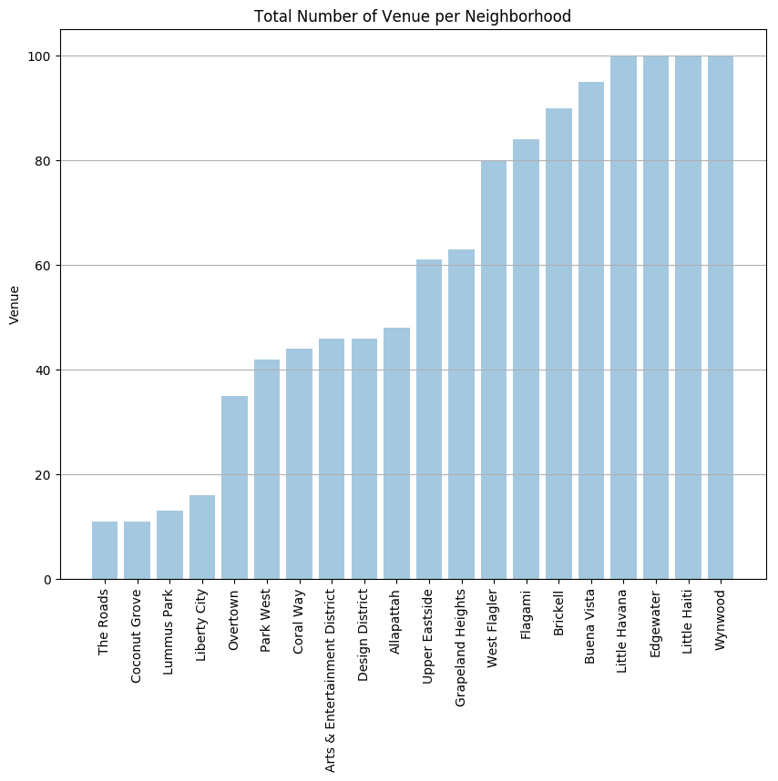

Analyzing this plot, we can clearly see that some neighorhoods have more venues than other one. In this cas, places like The Roads, Coconut Grove, Lummus Park and Liberty City seems to have a very small number of venues, which can maybe cause less interest for people to go there, and then it could be a bad place to open a new restaurant, just as places like Wynwood, Little Haiti, Edgewater and Little Havana seem to be already full of venu, with probably some Italian restaurant already opened there.

We can now use a one-hot encoding to get the frequency of each venue in each neighborhood.

|  | Neighborhood | ATM | Airport | Airport Service | American Restaurant | Aquarium | Arcade | Arepa Restaurant | Argentinian Restaurant | Art Gallery | Art Museum | Arts & Crafts Store | Asian Restaurant | Athletics & Sports | Auto Garage | Auto Workshop | Automotive Shop | Bakery | Bank | Bar | Baseball Field | Baseball Stadium | Basketball Stadium | Beer Bar | Beer Garden | Big Box Store | Bistro | Boat or Ferry | Boutique | … |
| --- | --- | --- | --- | --- | --- | --- | --- | --- | --- | --- | --- | --- | --- | --- | --- | --- | --- | --- | --- | --- | --- | --- | --- | --- | --- | --- | --- | --- | --- | --- |
| 0 | Allapattah | 0.0 | 0.0 | 0.0 | 0.000000 | 0.0 | 0.0 | 0.000000 | 0.000000 | 0.000000 | 0.000000 | 0.0 | 0.000000 | 0.020833 | 0.0 | 0.0 | 0.0 | 0.000000 | 0.000000 | 0.000000 | 0.000000 | 0.0 | 0.0 | 0.0 | 0.000000 | 0.000000 | 0.000000 | 0.000000 | 0.000000 | … |
| 1 | Arts & Entertainment District | 0.0 | 0.0 | 0.0 | 0.000000 | 0.0 | 0.0 | 0.000000 | 0.000000 | 0.043478 | 0.000000 | 0.0 | 0.000000 | 0.000000 | 0.0 | 0.0 | 0.0 | 0.000000 | 0.000000 | 0.000000 | 0.000000 | 0.0 | 0.0 | 0.0 | 0.021739 | 0.000000 | 0.000000 | 0.000000 | 0.000000 | … |
| 2 | Brickell | 0.0 | 0.0 | 0.0 | 0.022222 | 0.0 | 0.0 | 0.000000 | 0.033333 | 0.000000 | 0.000000 | 0.0 | 0.011111 | 0.011111 | 0.0 | 0.0 | 0.0 | 0.022222 | 0.011111 | 0.033333 | 0.000000 | 0.0 | 0.0 | 0.0 | 0.000000 | 0.000000 | 0.000000 | 0.000000 | 0.000000 | … |
| 3 | Buena Vista | 0.0 | 0.0 | 0.0 | 0.010526 | 0.0 | 0.0 | 0.010526 | 0.010526 | 0.031579 | 0.021053 | 0.0 | 0.010526 | 0.000000 | 0.0 | 0.0 | 0.0 | 0.010526 | 0.000000 | 0.010526 | 0.010526 | 0.0 | 0.0 | 0.0 | 0.000000 | 0.010526 | 0.010526 | 0.000000 | 0.021053 | … |
| 4 | Coconut Grove | 0.0 | 0.0 | 0.0 | 0.090909 | 0.0 | 0.0 | 0.000000 | 0.000000 | 0.000000 | 0.000000 | 0.0 | 0.000000 | 0.000000 | 0.0 | 0.0 | 0.0 | 0.000000 | 0.000000 | 0.000000 | 0.000000 | 0.0 | 0.0 | 0.0 | 0.000000 | 0.000000 | 0.000000 | 0.090909 | 0.000000 | … |

With these data, it's now possible to get the list of the top 10 most frequents kind of venue per neighborhood, using the following function.

|  | Neighborhood | 1st Most Common Venue | 2nd Most Common Venue | 3rd Most Common Venue | 4th Most Common Venue | 5th Most Common Venue | 6th Most Common Venue | 7th Most Common Venue | 8th Most Common Venue | 9th Most Common Venue | 10th Most Common Venue |
| --- | --- | --- | --- | --- | --- | --- | --- | --- | --- | --- | --- |
| 0 | Allapattah | Fast Food Restaurant | Gas Station | Park | Seafood Restaurant | Nightclub | Grocery Store | Fried Chicken Joint | Storage Facility | Discount Store | Light Rail Station |
| 1 | Arts & Entertainment District | Restaurant | Pizza Place | Ice Cream Shop | Sandwich Place | Gym | Art Gallery | Grocery Store | Park | Furniture / Home Store | Tapas Restaurant |
| 2 | Brickell | Hotel | Italian Restaurant | Japanese Restaurant | Bar | Gym | Argentinian Restaurant | Latin American Restaurant | Lounge | Spa | Pool |
| 3 | Buena Vista | Pizza Place | Café | Italian Restaurant | Art Gallery | Juice Bar | Park | Coffee Shop | Gym | Seafood Restaurant | Cosmetics Shop |
| 4 | Coconut Grove | Garden | Park | Trail | Plaza | Boat or Ferry | Harbor / Marina | Playground | Food Truck | American Restaurant | Dive Bar |

### 3.2. Clustering the neighborhoods into smaller groups

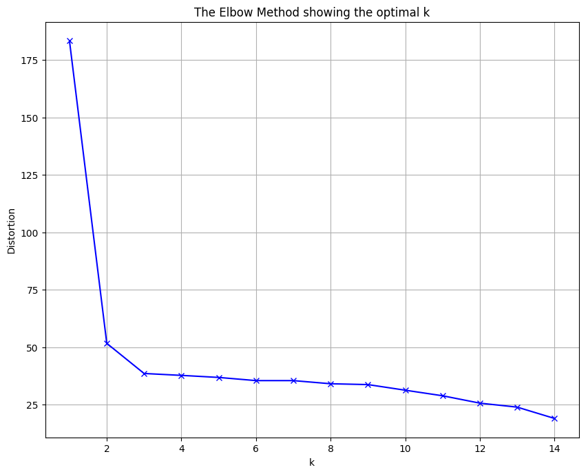

With this value of $k$, we got the following clusters :

|  | Neighborhood | Population | Density | Latitude | Longitude | Area | Cluster Labels | 1st Most Common Venue | 2nd Most Common Venue | 3rd Most Common Venue | 4th Most Common Venue | 5th Most Common Venue | 6th Most Common Venue | 7th Most Common Venue | 8th Most Common Venue | 9th Most Common Venue | 10th Most Common Venue |
| --- | --- | --- | --- | --- | --- | --- | --- | --- | --- | --- | --- | --- | --- | --- | --- | --- | --- |
| 0 | Allapattah | 54.289 | 4.401 | 25.815 | -80.224 | 12.3356 | 8 | Fast Food Restaurant | Gas Station | Park | Seafood Restaurant | Nightclub | Grocery Store | Fried Chicken Joint | Storage Facility | Discount Store | Light Rail Station |
| 1 | Arts & Entertainment District | 11.033 | 7.948 | 25.799 | -80.190 | 1.38815 | 1 | Restaurant | Pizza Place | Ice Cream Shop | Sandwich Place | Gym | Art Gallery | Grocery Store | Park | Furniture / Home Store | Tapas Restaurant |
| 2 | Brickell | 31.759 | 14.541 | 25.758 | -80.193 | 2.1841 | 6 | Hotel | Italian Restaurant | Japanese Restaurant | Bar | Gym | Argentinian Restaurant | Latin American Restaurant | Lounge | Spa | Pool |
| 3 | Buena Vista | 9.058 | 3.54 | 25.813 | -80.192 | 2.55876 | 6 | Pizza Place | Café | Italian Restaurant | Art Gallery | Juice Bar | Park | Coffee Shop | Gym | Seafood Restaurant | Cosmetics Shop |
| 4 | Coconut Grove | 20.076 | 3.091 | 25.712 | -80.257 | 6.49499 | 4 | Garden | Park | Trail | Plaza | Boat or Ferry | Harbor / Marina | Playground | Food Truck | American Restaurant | Dive Bar |
| 5 | Coral Way | 35.062 | 4.496 | 25.750 | -80.283 | 7.79849 | 6 | Golf Course | Pool | Café | Dance Studio | Italian Restaurant | Cuban Restaurant | Breakfast Spot | Burger Joint | Canal Lock | Cocktail Bar |
| 6 | Design District | 3.573 | 3.623 | 25.813 | -80.193 | 0.986199 | 6 | Italian Restaurant | Art Museum | Clothing Store | Shopping Mall | Café | Coffee Shop | Boutique | Jewelry Store | Cosmetics Shop | Ice Cream Shop |
| 8 | Edgewater | 15.005 | 6.675 | 25.802 | -80.190 | 2.24794 | 1 | Art Gallery | Restaurant | Ice Cream Shop | Coffee Shop | Sandwich Place | Gym / Fitness Center | Pizza Place | Furniture / Home Store | Park | Italian Restaurant |
| 9 | Flagami | 50.834 | 5.665 | 25.762 | -80.316 | 8.97335 | 8 | Fast Food Restaurant | Cuban Restaurant | Bakery | Video Game Store | Latin American Restaurant | Gas Station | Grocery Store | Seafood Restaurant | Sandwich Place | Chinese Restaurant |
| 10 | Grapeland Heights | 14.004 | 4.13 | 25.792 | -80.258 | 3.3908 | 3 | Rental Car Location | Hotel | Hotel Pool | Train Station | Bus Station | Gym / Fitness Center | Gym | Bus Line | Business Service | Coffee Shop |
| 11 | Liberty City | 19.725 | 3.733 | 25.832 | -80.225 | 5.28395 | 7 | Discount Store | Fried Chicken Joint | ATM | Athletics & Sports | Construction & Landscaping | Sandwich Place | Chinese Restaurant | Seafood Restaurant | Shop & Service | Donut Shop |
| 12 | Little Haiti | 29.760 | 3.84 | 25.824 | -80.191 | 7.75 | 6 | Art Gallery | Pizza Place | Boutique | Café | Italian Restaurant | Gym | Caribbean Restaurant | Coffee Shop | Pharmacy | Sandwich Place |
| 13 | Little Havana | 76.163 | 8.423 | 25.773 | -80.215 | 9.04227 | 8 | Cuban Restaurant | Mexican Restaurant | Smoke Shop | Pizza Place | Grocery Store | Seafood Restaurant | Latin American Restaurant | Bar | Spanish Restaurant | Fast Food Restaurant |
| 14 | Lummus Park | 3.027 | 3.68 | 25.777 | -80.201 | 0.822554 | 2 | Seafood Restaurant | Fish Market | Museum | Restaurant | Hotel | American Restaurant | Spanish Restaurant | Harbor / Marina | Soccer Field | Event Space |
| 16 | Overtown | 6.736 | 3.405 | 25.787 | -80.201 | 1.97827 | 9 | Park | Nightclub | Restaurant | Coffee Shop | Bar | American Restaurant | Art Gallery | Speakeasy | Chinese Restaurant | Event Space |
| 17 | Park West | 4.655 | 3.635 | 25.785 | -80.193 | 1.28061 | 9 | Café | Nightclub | Theater | Lounge | Performing Arts Venue | Gym / Fitness Center | Art Gallery | Science Museum | Pizza Place | Light Rail Station |
| 18 | The Roads | 7.327 | 4.899 | 25.756 | -80.207 | 1.49561 | 5 | Flower Shop | Salon / Barbershop | Health & Beauty Service | Lawyer | Latin American Restaurant | Gas Station | Italian Restaurant | Hotel | American Restaurant | Event Service |
| 19 | Upper Eastside | 12.525 | 2.513 | 25.830 | -80.183 | 4.98408 | 6 | Park | Italian Restaurant | Gym | Pizza Place | Gas Station | Coffee Shop | Sushi Restaurant | Argentinian Restaurant | American Restaurant | Pub |
| 22 | West Flagler | 31.407 | 4.428 | 25.775 | -80.243 | 7.09282 | 0 | Latin American Restaurant | Bakery | Fast Food Restaurant | Grocery Store | Pizza Place | Cuban Restaurant | Casino | Chinese Restaurant | Cosmetics Shop | Pharmacy |
| 23 | Wynwood | 7.277 | 2.983 | 25.804 | -80.199 | 2.43949 | 1 | Art Gallery | Restaurant | Bar | Ice Cream Shop | Food Truck | Coffee Shop | Asian Restaurant | Pizza Place | Brewery | Gym / Fitness Center |

Make this Notebook Trusted to load map: File -> Trust Notebook

[interactive chart not shown]

## 4. Discussion

### 4.1. Analyse of our results

As we can see in our dataframe and on our map, there is only one other neighborhood in the same cluster as Park West, which is the neighborhood of **Overtown**, as we can see by isolating this cluster.

|  | Neighborhood | Cluster Labels | 1st Most Common Venue | 2nd Most Common Venue | 3rd Most Common Venue | 4th Most Common Venue | 5th Most Common Venue | 6th Most Common Venue | 7th Most Common Venue | 8th Most Common Venue | 9th Most Common Venue | 10th Most Common Venue |
| --- | --- | --- | --- | --- | --- | --- | --- | --- | --- | --- | --- | --- |
| 16 | Overtown | 9 | Park | Nightclub | Restaurant | Coffee Shop | Bar | American Restaurant | Art Gallery | Speakeasy | Chinese Restaurant | Event Space |
| 17 | Park West | 9 | Café | Nightclub | Theater | Lounge | Performing Arts Venue | Gym / Fitness Center | Art Gallery | Science Museum | Pizza Place | Light Rail Station |

Now we can get the list of all the italian restaurants and pizza places of our cluster, by limiting our research to the two neighborhoods present in our cluster :

|  | Neighborhood | Neighborhood Latitude | Neighborhood Longitude | Venue | Venue Latitude | Venue Longitude | Venue Category |
| --- | --- | --- | --- | --- | --- | --- | --- |
| 905 | Park West | 25.785 | -80.193 | Pucci's Pizza | 25.782944 | -80.189953 | Pizza Place |

And here we are with a great news !!! There is only one Pizza place in the cluster, the *Pucci's Pizza*, which is the famous restaurant we based our analysis on. On the first hand, it can explain why this pizzeria is famous and always full, being the one and only italian place in its neighborhood, while on the other hand it tells us there is no italian restaurant in the Overtown neighborhood, making it the perfect place to open a new one !!!

And this is were we can see the clustering methods is really effective, because it has been able to separate neighborhoods like Park West and Overtown, having almost no Italian places to groups like cluster n°6, where Italian restaurant and Pizza place are almost always in the top-5 of the most frequents venues :

|  | Neighborhood | Cluster Labels | 1st Most Common Venue | 2nd Most Common Venue | 3rd Most Common Venue | 4th Most Common Venue | 5th Most Common Venue | 6th Most Common Venue | 7th Most Common Venue | 8th Most Common Venue | 9th Most Common Venue | 10th Most Common Venue |
| --- | --- | --- | --- | --- | --- | --- | --- | --- | --- | --- | --- | --- |
| 2 | Brickell | 6 | Hotel | Italian Restaurant | Japanese Restaurant | Bar | Gym | Argentinian Restaurant | Latin American Restaurant | Lounge | Spa | Pool |
| 3 | Buena Vista | 6 | Pizza Place | Café | Italian Restaurant | Art Gallery | Juice Bar | Park | Coffee Shop | Gym | Seafood Restaurant | Cosmetics Shop |
| 5 | Coral Way | 6 | Golf Course | Pool | Café | Dance Studio | Italian Restaurant | Cuban Restaurant | Breakfast Spot | Burger Joint | Canal Lock | Cocktail Bar |
| 6 | Design District | 6 | Italian Restaurant | Art Museum | Clothing Store | Shopping Mall | Café | Coffee Shop | Boutique | Jewelry Store | Cosmetics Shop | Ice Cream Shop |
| 12 | Little Haiti | 6 | Art Gallery | Pizza Place | Boutique | Café | Italian Restaurant | Gym | Caribbean Restaurant | Coffee Shop | Pharmacy | Sandwich Place |
| 19 | Upper Eastside | 6 | Park | Italian Restaurant | Gym | Pizza Place | Gas Station | Coffee Shop | Sushi Restaurant | Argentinian Restaurant | American Restaurant | Pub |

### 4.2. Validation of our results

Last but not least, we have to be sure that Overtown and Park West are similar before telling our client this is the perfect place to open a pizzeria. Indeed, event if the clustering method seems to have given logical results, a verification step is always worthy.

In order to validate our results, we can simply analyse the most frequent venues in each neighborhood. A quick and visual comparison can be done with the following heatmap, showing the frequency of each venu according to the neighborhood.

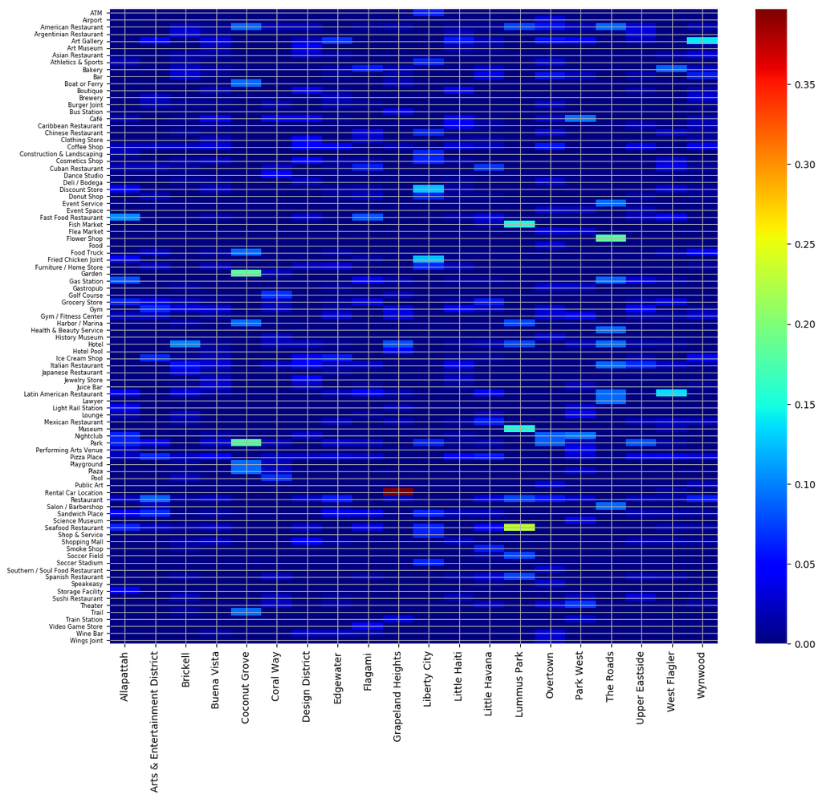

This map can tell us that Overtown is indeed a good location to open an Italian Restaurant, as there are a lot of other venues, such as an Airport, some Cafés, lots of shops and even a theater, but no italian place, which can confort our results. Anyway, it's really complicated to tell if Overtown is really similar to PArk West according to this map. To answer this last question, we will have to look at another heatmab, based on the correlation matrix between the venues, as shown below.

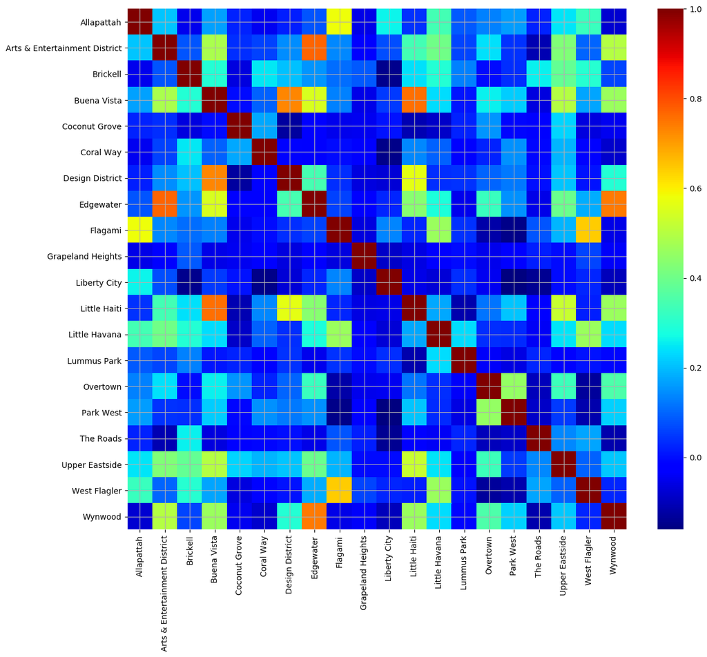

And ... Here we are, with the obvious observation that Overtown and Park West are clearly correlated, making us able to validate the idea that **Overtown is the perfect neighborhood to open a new italian restaurant** !

## 4. Conclusion

Miami is a rich and big city with a lot a cultural mixity. This diversity make it the perfect city to open a new business, may it be a restaurant, a sport shop, and so on. In this report, we investigate the possibility to open a new Italian restaurant, and tryed to find the best place for this new opening.

Our method, based on k-means clustering by comparing the neighborhoods according to the venus in each one of them, has shown great results, giving us the perfect location to open a new Italian restaurant. Validated with an analysis of the correlation between each neighborhood, our methods seems really great for this task, giving us an interesting methodology for anyone who would like to open a new business in any city in the world !

## 5. Reference

- [Miami's neighborhood description](https://www.miamiandbeaches.com/neighborhoods);
- [Miami's Wikipedia page](https://en.wikipedia.org/wiki/Miami);
- [Miami's neighborhood numerical data](https://en.wikipedia.org/wiki/List_of_neighborhoods_in_Miami);
- [Foursquare API's documentation](https://developer.foursquare.com/docs/);
- [scikit-learn k-means clustering](https://scikit-learn.org/stable/modules/generated/sklearn.cluster.KMeans.html).